Clayton Cohn  
April 21, 2020  
DSC 478  
Prof. Mobasher

# Assignment 2

1. K-Nearest-Neighbor (KNN) classification on Newsgroups [Dataset: newsgroups.zip]

```python
import pandas as pd

DATA_PATH = "/Users/claytoncohn/Dropbox/New/DePaul/DSC478/data/newsgroups/"
```

**1. For this problem you will use a subset of the 20 Newsgroup data set.**

- The full data set contains 20,000 newsgroup documents
- Partitioned (nearly) evenly across 20 different newsgroups
- The assignment data set contains a subset of 1000 documents and a vocabulary of 5,500 terms
- Each document belongs to one of two classes Hockey (class label 1) and Microsoft Windows (class label 0)
- The data has already been split (80%, 20%) into training and test data
- The class labels for the training and test data are also provided in separate files
- The training and test data are on term x document format: row for each term, column for each document.
- The values in the table represent raw term occurence counts.
- The data has already been preprocessed to extract tokens, remove stop words and perform stemming (so, the terms in the vocabulary are stems not full terms).
- Please be sure to read the readme.txt file in the distribution.

```python
#Preset training data
train_data = pd.read_table(DATA_PATH + "trainMatrixModified.txt", header=None)
train_labels = pd.read_table(DATA_PATH + "trainClasses.txt", header=None, index_col=0)
train_labels.head()
```

| 0 | 1 |
| --- | --- |
| 0 | 0 |
| 1 | 1 |
| 2 | 0 |
| 3 | 1 |
| 4 | 0 |

```python
#Preset testing data
test_data = pd.read_table(DATA_PATH + "testMatrixModified.txt", header=None)
test_labels = pd.read_table(DATA_PATH + "testClasses.txt", header=None, index_col=0)
test_data.head()
```

|  | 0 | 1 | 2 | 3 | 4 | 5 | 6 | 7 | 8 | 9 | ... | 190 | 191 | 192 | 193 | 194 | 195 | 196 | 197 | 198 | 199 |
| --- | --- | --- | --- | --- | --- | --- | --- | --- | --- | --- | --- | --- | --- | --- | --- | --- | --- | --- | --- | --- | --- |
| 0 | 0.0 | 0.0 | 1.0 | 0.0 | 0.0 | 0.0 | 0.0 | 0.0 | 0.0 | 0.0 | ... | 0.0 | 0.0 | 0.0 | 0.0 | 0.0 | 0.0 | 0.0 | 0.0 | 0.0 | 0.0 |
| 1 | 0.0 | 0.0 | 0.0 | 0.0 | 0.0 | 0.0 | 0.0 | 0.0 | 0.0 | 0.0 | ... | 0.0 | 0.0 | 0.0 | 0.0 | 0.0 | 0.0 | 0.0 | 0.0 | 0.0 | 0.0 |
| 2 | 0.0 | 0.0 | 0.0 | 0.0 | 0.0 | 0.0 | 0.0 | 0.0 | 0.0 | 0.0 | ... | 0.0 | 0.0 | 0.0 | 0.0 | 0.0 | 0.0 | 0.0 | 0.0 | 0.0 | 0.0 |
| 3 | 1.0 | 1.0 | 1.0 | 1.0 | 1.0 | 1.0 | 2.0 | 1.0 | 1.0 | 1.0 | ... | 1.0 | 2.0 | 1.0 | 1.0 | 1.0 | 1.0 | 1.0 | 1.0 | 1.0 | 1.0 |
| 4 | 0.0 | 0.0 | 0.0 | 0.0 | 0.0 | 0.0 | 0.0 | 0.0 | 2.0 | 0.0 | ... | 0.0 | 0.0 | 0.0 | 0.0 | 0.0 | 0.0 | 0.0 | 0.0 | 0.0 | 0.0 |

5 rows × 200 columns

```python
train_data.shape
```

```
(5500, 800)
```

```python
test_data.shape
```

```
(5500, 200)
```

```python
#Convert training and testing data from TD to DT
dt_train = train_data.T
dt_test = test_data.T
dt_train.head()
```

|  | 0 | 1 | 2 | 3 | 4 | 5 | 6 | 7 | 8 | 9 | ... | 5490 | 5491 | 5492 | 5493 | 5494 | 5495 | 5496 | 5497 | 5498 | 5499 |
| --- | --- | --- | --- | --- | --- | --- | --- | --- | --- | --- | --- | --- | --- | --- | --- | --- | --- | --- | --- | --- | --- |
| 0 | 2.0 | 2.0 | 2.0 | 1.0 | 8.0 | 6.0 | 2.0 | 8.0 | 2.0 | 4.0 | ... | 0.0 | 0.0 | 0.0 | 0.0 | 0.0 | 0.0 | 0.0 | 0.0 | 0.0 | 0.0 |
| 1 | 0.0 | 0.0 | 0.0 | 1.0 | 1.0 | 0.0 | 0.0 | 0.0 | 0.0 | 0.0 | ... | 0.0 | 0.0 | 0.0 | 0.0 | 0.0 | 0.0 | 0.0 | 0.0 | 0.0 | 0.0 |
| 2 | 0.0 | 0.0 | 0.0 | 1.0 | 0.0 | 0.0 | 0.0 | 2.0 | 0.0 | 1.0 | ... | 0.0 | 0.0 | 0.0 | 0.0 | 0.0 | 0.0 | 0.0 | 0.0 | 0.0 | 0.0 |
| 3 | 2.0 | 0.0 | 0.0 | 1.0 | 0.0 | 0.0 | 0.0 | 0.0 | 0.0 | 0.0 | ... | 0.0 | 0.0 | 0.0 | 0.0 | 0.0 | 0.0 | 0.0 | 0.0 | 0.0 | 0.0 |
| 4 | 2.0 | 0.0 | 0.0 | 1.0 | 0.0 | 0.0 | 0.0 | 0.0 | 0.0 | 0.0 | ... | 0.0 | 0.0 | 0.0 | 0.0 | 0.0 | 0.0 | 0.0 | 0.0 | 0.0 | 0.0 |

5 rows × 5500 columns

Your tasks in this problem are the following:  
[Note: for this problem you should not use scikit-learn for classification, but create your own KNN classifer. You may use Pandas, NumPy, standard Python libraries, and Matplotlib.]

Create your own KNN classifier function.  
Your classifier should allow as input the training data matrix, the training labels, the instance to be classified, the value of K, and should return the predicted class for the instance and the indices of the top K neighbors.  
Your classifier should work with Euclidean distance as well as Cosine distance (which is 1 minus the Cosine similarity). You may create two separate classifiers, or add the distance metric as a parameter in the classifier function.

```python
import numpy as np

# kNN search method from the lecture slides
def knn_search(x, D, K, measure):
    """ find K nearest neighbors of an instance x among the instances in D """
    if measure == 0:
        # euclidean distances from the other points
        dists = np.sqrt(((D - x)**2).sum(axis=1))
    elif measure == 1:
        # first find the vector norm for each instance in D as wel as the norm for vector x
        D_norm = np.array([np.linalg.norm(D[i]) for i in range(len(D))])
        x_norm = np.linalg.norm(x)
        # Compute Cosine: divide the dot product o x and each instance in D by the product of the two norms
        sims = np.dot(D,x)/(D_norm * x_norm)
        # The distance measure will be the inverse of Cosine similarity
        dists = 1 - sims
    idx = np.argsort(dists) # sorting
    # return the indexes of K nearest neighbors
    return idx[:K], dists
```

```python
# kNN classify method from the lecture slides
def knn_classify(x, D, K, labels, measure):
    from collections import Counter
    neigh_idx, distances = knn_search(x, D, K, measure)
    neigh_labels = labels[neigh_idx]
    count = Counter(neigh_labels)
    return count.most_common(1)[0][0]
```

Create an evaluation function to measure the accuracy of your classifier. This function will call the classifier function in part a on all the test instances and in each case compares the actual test class label to the predicted class label. It should take as input the training data, the training labels, the test instances, the labels for test instances, and the value of K. Your evaluation function should return the Classification Accuracy (ratio of correct predictions to the number of test instances) [See class notes: Classification & Prediction - Review of Basic Concepts].

```python
def knn_evaluate(test_data, test_labels, train_data, train_labels, K, measure):
    total = len(test_data)
    correct = 0
    for i in range(len(test_data)):
        label = knn_classify(test_data[i],train_data,K,train_labels,measure)
        if label == test_labels[i]:
            correct += 1
    return correct/total
```

Run your evaluation function on a range of values for K from 5 to 100 (in increments of 5) in order to compare accuracy values for different numbers of neighbors. Do this both using Euclidean Distance as well as Cosine similarity measure. Present the results as graphs with K in the x-axis and the evaluation metric (accuracy) on the y-axis.

```python
# Data prep
dtm_train = np.array(dt_train)
dtm_test = np.array(dt_test)
train_labels_arr = np.array(train_labels).flatten()
test_labels_arr = np.array(test_labels).flatten()
```

```python
%%time

#Euclidean
euclidean_reg = []
for K in range (5,101,5):
    euclidean_reg.append(knn_evaluate(dtm_test,test_labels_arr,dtm_train,train_labels_arr,K,0))
```

```
CPU times: user 1min 20s, sys: 12.1 s, total: 1min 32s
Wall time: 1min 33s
```

```python
%%time

# Cosine
cosine_reg = []
for K in range (5,101,5):
    cosine_reg.append(knn_evaluate(dtm_test,test_labels_arr,dtm_train,train_labels_arr,K,1))
```

```
CPU times: user 2min 19s, sys: 511 ms, total: 2min 20s
Wall time: 1min 11s
```

Use a single plot to compare the two version of the classifier (Eculidean distance version vs. cosine similarity version).

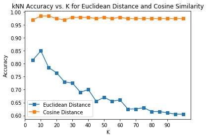

```python
import matplotlib.pyplot as plt
%matplotlib inline

x = list(range(5, 101, 5))

plt.plot(x, euclidean_reg, label='Euclidean Distance', marker="s")
plt.plot(x, cosine_reg, label='Cosine Distance',marker="s")

plt.xlabel('K')
plt.xticks(range(0,100,10))

plt.ylabel('Accuracy')
plt.title('kNN Accuracy vs. K for Euclidean Distance and Cosine Similarity')
plt.legend(loc = 'best')
plt.show()
```

Next, modify the training and test data sets so that term weights are converted to TFxIDF weights (instead of raw term frequencies). [See class notes on Text Categorization]. Then, rerun your evaluation (only for the Cosine similairty version of the classifier) on the range of K values (as above) and compare the results to the results without using TFxIDF weights.

```python
nTerms = dtm_train.shape[1]
nTerms
```

```
5500
```

```python
nDocs = dtm_train.shape[0]
nDocs
```

```
800
```

```python
# Get the doc counts for each term
doc_terms = pd.DataFrame([(train_data!=0).sum(1)]).T
```

```python
# Create a matrix with all of the entries (nDocs)
nMatrix = np.ones(np.shape(train_data), dtype=float) * nDocs
np.set_printoptions(precision=2,suppress=True,linewidth=120)
print(nMatrix)
```

```
[[800. 800. 800. ... 800. 800. 800.]
 [800. 800. 800. ... 800. 800. 800.]
 [800. 800. 800. ... 800. 800. 800.]
 ...
 [800. 800. 800. ... 800. 800. 800.]
 [800. 800. 800. ... 800. 800. 800.]
 [800. 800. 800. ... 800. 800. 800.]]
```

```python
# Map array to IDF values (IDF = log of inverse of document freq)
# IDF only a function of term, so all columns will be the same.

IDF = np.log2(np.divide(nMatrix, np.array(doc_terms)))
IDF[0:5]
```

```
array([[4.  , 4.  , 4.  , ..., 4.  , 4.  , 4.  ],
       [6.84, 6.84, 6.84, ..., 6.84, 6.84, 6.84],
       [6.32, 6.32, 6.32, ..., 6.32, 6.32, 6.32],
       [0.  , 0.  , 0.  , ..., 0.  , 0.  , 0.  ],
       [2.89, 2.89, 2.89, ..., 2.89, 2.89, 2.89]])
```

```python
# Compute TFxIDF values for each document-term entry. This is our matrix.
TD_tfidf = train_data * IDF
TD_tfidf.sample(10)
```

|  | 0 | 1 | 2 | 3 | 4 | 5 | 6 | 7 | 8 | 9 | ... | 790 | 791 | 792 | 793 | 794 | 795 | 796 | 797 | 798 | 799 |
| --- | --- | --- | --- | --- | --- | --- | --- | --- | --- | --- | --- | --- | --- | --- | --- | --- | --- | --- | --- | --- | --- |
| 3878 | 0.0 | 0.0 | 0.0 | 0.0 | 0.0 | 0.000000 | 0.0 | 0.0 | 0.0 | 0.0 | ... | 0.0 | 0.0 | 0.0 | 0.0 | 0.0 | 0.0 | 0.0 | 0.000000 | 0.0 | 0.0 |
| 2483 | 0.0 | 0.0 | 0.0 | 0.0 | 0.0 | 0.000000 | 0.0 | 0.0 | 0.0 | 0.0 | ... | 0.0 | 0.0 | 0.0 | 0.0 | 0.0 | 0.0 | 0.0 | 0.000000 | 0.0 | 0.0 |
| 4962 | 0.0 | 0.0 | 0.0 | 0.0 | 0.0 | 0.000000 | 0.0 | 0.0 | 0.0 | 0.0 | ... | 0.0 | 0.0 | 0.0 | 0.0 | 0.0 | 0.0 | 0.0 | 0.000000 | 0.0 | 0.0 |
| 4026 | 0.0 | 0.0 | 0.0 | 0.0 | 0.0 | 0.000000 | 0.0 | 0.0 | 0.0 | 0.0 | ... | 0.0 | 0.0 | 0.0 | 0.0 | 0.0 | 0.0 | 0.0 | 0.000000 | 0.0 | 0.0 |
| 1723 | 0.0 | 0.0 | 0.0 | 0.0 | 0.0 | 0.000000 | 0.0 | 0.0 | 0.0 | 0.0 | ... | 0.0 | 0.0 | 0.0 | 0.0 | 0.0 | 0.0 | 0.0 | 0.000000 | 0.0 | 0.0 |
| 265 | 0.0 | 0.0 | 0.0 | 0.0 | 0.0 | 10.240588 | 0.0 | 0.0 | 0.0 | 0.0 | ... | 0.0 | 0.0 | 0.0 | 0.0 | 0.0 | 0.0 | 0.0 | 0.000000 | 0.0 | 0.0 |
| 2045 | 0.0 | 0.0 | 0.0 | 0.0 | 0.0 | 0.000000 | 0.0 | 0.0 | 0.0 | 0.0 | ... | 0.0 | 0.0 | 0.0 | 0.0 | 0.0 | 0.0 | 0.0 | 0.000000 | 0.0 | 0.0 |
| 3412 | 0.0 | 0.0 | 0.0 | 0.0 | 0.0 | 0.000000 | 0.0 | 0.0 | 0.0 | 0.0 | ... | 0.0 | 0.0 | 0.0 | 0.0 | 0.0 | 0.0 | 0.0 | 0.000000 | 0.0 | 0.0 |
| 3547 | 0.0 | 0.0 | 0.0 | 0.0 | 0.0 | 0.000000 | 0.0 | 0.0 | 0.0 | 0.0 | ... | 0.0 | 0.0 | 0.0 | 0.0 | 0.0 | 0.0 | 0.0 | 8.058894 | 0.0 | 0.0 |
| 2368 | 0.0 | 0.0 | 0.0 | 0.0 | 0.0 | 0.000000 | 0.0 | 0.0 | 0.0 | 0.0 | ... | 0.0 | 0.0 | 0.0 | 0.0 | 0.0 | 0.0 | 0.0 | 0.000000 | 0.0 | 0.0 |

10 rows × 800 columns

```python
# kNN Search needs document by term matrix as np array, so we need to transpose
DT_tfidf = TD_tfidf.T
dtm_train_idf = np.array(DT_tfidf)
dtm_train_idf
```

```
array([[ 8.  , 13.67, 12.64, ...,  0.  ,  0.  ,  0.  ],
       [ 0.  ,  0.  ,  0.  , ...,  0.  ,  0.  ,  0.  ],
       [ 0.  ,  0.  ,  0.  , ...,  0.  ,  0.  ,  0.  ],
       ...,
       [ 0.  ,  0.  ,  0.  , ...,  0.  ,  0.  ,  0.  ],
       [ 0.  ,  0.  ,  0.  , ...,  0.  ,  0.  ,  0.  ],
       [ 0.  ,  0.  ,  0.  , ...,  0.  ,  0.  ,  0.  ]])
```

```python
def knn_evaluate_idf(test_data, test_labels, train_data, train_labels, K, measure):
    total = len(test_data)
    correct = 0

    for i in range(len(test_data)):

        # During evaluation, each input must be multiplied by the idf value of the term
        x_tfidf = test_data[i] * IDF.T[i]

        label = knn_classify(x_tfidf,train_data,K,train_labels,measure)
        if label == test_labels[i]:
            correct += 1
    return correct/total
```

```python
%%time

# Cosine
cosine_idf = []
for K in range (5,101,5):
    cosine_idf.append(knn_evaluate_idf(dtm_test,test_labels_arr,dtm_train_idf,train_labels_arr,K,1))
```

```
CPU times: user 10min 25s, sys: 6.96 s, total: 10min 32s
Wall time: 5min 23s
```

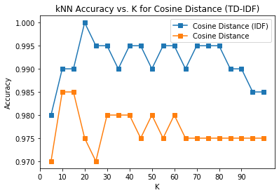

```python
plt.clf()
plt.cla()
plt.close()

x = list(range(5, 101, 5))

plt.plot(x, cosine_idf, label='Cosine Distance (IDF)',marker="s")
plt.plot(x, cosine_reg, label='Cosine Distance',marker="s")

plt.xlabel('K')
plt.xticks(range(0,100,10))

plt.ylabel('Accuracy')
plt.title('kNN Accuracy vs. K for Cosine Distance (TD-IDF)')
plt.legend(loc = 'best')
plt.show()
```

Comparing the two Cosine Distances above, we can see that the IDF version is better by about 1.5 - 2% on average.

Create a new classifier based on the Rocchio Method adapted for text categorization [See class notes on Text Categorization].

You should separate the training function from the classifiation function. The training part for the classifier can be implemented as a function that takes as input the training data matrix and the training labels, returning the prototype vectors for each class.

```python
# First without TDIDF
def rocchio_train(data,labels):

    n_rows, n_cols = data.shape

    # Get a list of all the classes
    classes =  np.unique(labels)

    # Create array of prototypes to return later
    prototypes = {}

    # For each class
    for (i, cls) in enumerate(classes):

        # Get indexes of all documents that match our class
        indexes = np.array(labels.index[labels.iloc[:, 0] == cls])

        # Get all rows (documents) of data that belong to this class)
        docs = data[indexes]

        # Add up all rows to get the prototype for the class
        p = np.sum(docs,axis=0)

        # Add each prototype to the result
        prototypes.update( {i : p} )

    # Return the array of prototypes
    return prototypes
```

The classification part can be implemented as another function that would take as input the prototypes returned from the training function and the instance to be classified. This function should measure Cosine similarity of the test instance to each prototype vector. Your output should indicate the predicted class for the test instance and the similarity values of the instance to each of the category prototypes.

```python
from numpy import dot
from numpy.linalg import norm

def rocchio_classify(prototypes, instance):

    cs_best = -1
    p_best = -1

    # Obtain cosine similarity between instance and each prototype
    for k, v in prototypes.items():
        cs = dot(instance, v)/(norm(instance)*norm(v))

        # If cosine similarity greater than previous best, replace it
        if cs > cs_best:
            cs_best = cs

            # Update the most_likely prototype class
            p_best = k

    return p_best
```

Finally, use your evaluation function to compare your results to the best KNN results you obtained in part d. [Note: your functions should work regardless of the number of categories (class labels) and should not be limited to two-class categorization scenario.]

```python
# Store the prototypes - first for the total frequency, not the TFIDF
prototypes = rocchio_train(dtm_train,train_labels)
```

```python
def rocchio_evaluate(data, labels, prototypes):
    total = len(data)
    correct = 0

    for i in range(len(data)):
        label = rocchio_classify(prototypes,data[i])
        if label == labels[i]:
            correct += 1
    print("Correct: {}, Total: {}".format(correct,total))
    return correct/total
```

```python
# Evaluate the accuracy of the test set for non-TFIDF
rocchio_evaluate(dtm_test,test_labels_arr,prototypes)
```

```
Correct: 195, Total: 200
```

```
0.975
```

```python
# Now evaluate for TFIDF
prototypes_idf = rocchio_train(dtm_train_idf,train_labels)
```

```python
def rocchio_evaluate_idf(data, labels, prototypes):
    total = len(data)
    correct = 0

    for i in range(len(data)):
        x_tfidf = data[i] * IDF.T[i]
        label = rocchio_classify(prototypes,x_tfidf)
        if label == labels[i]:
            correct += 1
    print("Correct: {}, Total: {}".format(correct,total))
    return correct/total
```

```python
rocchio_evaluate_idf(dtm_test,test_labels_arr,prototypes_idf)
```

```
Correct: 196, Total: 200
```

```
0.98
```

The best kNN score I got was 100%, which was with the kNN Consine Distance IDF with k=20, but the average for the kNN Cosine Distance IDF was about 99.5%. With the Rocchio, I got 97.5% with the raw frequencies and 98% with the IDF. Although the kNN did outperform the Rocchio, it's important to note that the Rocchio is much faster.

**2. Classification using scikit-learn [Dataset: bank_data.csv] For this problem you will experiment with various classifiers provided as part of the scikit-learn (sklearn) machine learning module, as well as with some of its preprocessing and model evaluation capabilities.**

[Note: This module is already part of the Anaconda distributions. You will work with a modified subset of a real data set of customers for a bank. This is the same data set used in Assignment 1. The data is provided in a CSV formatted file with the first row containing the attribute names. The description of the the different fields in the data are provided in this document.

```python
DATA_PATH = "/Users/claytoncohn/Dropbox/New/DePaul/DSC478/data/bank_data2.csv"
```

Load and preprocess the data using Pandas or similar tools.

```python
X = pd.read_csv(DATA_PATH)

# Get rid of id
X = X.drop('id',1)

X.head(10)
```

|  | age | income | children | gender | region | married | car | savings_acct | current_acct | mortgage | pep |
| --- | --- | --- | --- | --- | --- | --- | --- | --- | --- | --- | --- |
| 0 | 48 | 17546.00 | 1 | FEMALE | INNER_CITY | NO | NO | NO | NO | NO | YES |
| 1 | 40 | 30085.10 | 3 | MALE | TOWN | YES | YES | NO | YES | YES | NO |
| 2 | 51 | 16575.40 | 0 | FEMALE | INNER_CITY | YES | YES | YES | YES | NO | NO |
| 3 | 23 | 20375.40 | 3 | FEMALE | TOWN | YES | NO | NO | YES | NO | NO |
| 4 | 57 | 50576.30 | 0 | FEMALE | RURAL | YES | NO | YES | NO | NO | NO |
| 5 | 57 | 37869.60 | 2 | FEMALE | TOWN | YES | NO | YES | YES | NO | YES |
| 6 | 22 | 8877.07 | 0 | MALE | RURAL | NO | NO | NO | YES | NO | YES |
| 7 | 58 | 24946.60 | 0 | MALE | TOWN | YES | YES | YES | YES | NO | NO |
| 8 | 37 | 25304.30 | 2 | FEMALE | SUBURBAN | YES | YES | NO | NO | NO | NO |
| 9 | 54 | 24212.10 | 2 | MALE | TOWN | YES | YES | YES | YES | NO | NO |

Specifically, you need to separate the target attribute ("pep") from the portion of the data to be used for training and testing.

```python
y = X['pep']
X = X.drop('pep',1)
y.head(10)
```

```
0    YES
1     NO
2     NO
3     NO
4     NO
5    YES
6    YES
7     NO
8     NO
9     NO
Name: pep, dtype: object
```

You will need to convert the selected dataset into the Standard Spreadsheet format (i.e., convert categorical attributes into numeric by creating dummy variables).

```python
X_ssf = pd.get_dummies(X,columns=['gender','region','married','car','savings_acct',
                                    'current_acct','mortgage'])
X_ssf.sample(10)
```

|  | age | income | children | gender_FEMALE | gender_MALE | region_INNER_CITY | region_RURAL | region_SUBURBAN | region_TOWN | married_NO | married_YES | car_NO | car_YES | savings_acct_NO | savings_acct_YES | current_acct_NO | current_acct_YES | mortgage_NO | mortgage_YES |
| --- | --- | --- | --- | --- | --- | --- | --- | --- | --- | --- | --- | --- | --- | --- | --- | --- | --- | --- | --- |
| 60 | 42 | 24763.30 | 1 | 1 | 0 | 1 | 0 | 0 | 0 | 0 | 1 | 1 | 0 | 0 | 1 | 0 | 1 | 0 | 1 |
| 545 | 40 | 36256.90 | 0 | 0 | 1 | 1 | 0 | 0 | 0 | 1 | 0 | 1 | 0 | 1 | 0 | 0 | 1 | 0 | 1 |
| 212 | 22 | 14433.40 | 0 | 0 | 1 | 1 | 0 | 0 | 0 | 0 | 1 | 0 | 1 | 0 | 1 | 0 | 1 | 1 | 0 |
| 512 | 63 | 43943.00 | 0 | 1 | 0 | 0 | 0 | 0 | 1 | 0 | 1 | 0 | 1 | 0 | 1 | 0 | 1 | 0 | 1 |
| 501 | 58 | 33007.30 | 1 | 1 | 0 | 1 | 0 | 0 | 0 | 1 | 0 | 0 | 1 | 1 | 0 | 0 | 1 | 1 | 0 |
| 325 | 24 | 9465.21 | 0 | 1 | 0 | 0 | 0 | 0 | 1 | 1 | 0 | 1 | 0 | 1 | 0 | 0 | 1 | 1 | 0 |
| 73 | 58 | 23197.50 | 2 | 1 | 0 | 1 | 0 | 0 | 0 | 0 | 1 | 1 | 0 | 0 | 1 | 1 | 0 | 0 | 1 |
| 94 | 61 | 41127.40 | 0 | 1 | 0 | 1 | 0 | 0 | 0 | 0 | 1 | 0 | 1 | 0 | 1 | 1 | 0 | 1 | 0 |
| 50 | 24 | 14309.70 | 2 | 0 | 1 | 0 | 0 | 0 | 1 | 1 | 0 | 0 | 1 | 0 | 1 | 1 | 0 | 1 | 0 |
| 97 | 34 | 30870.80 | 2 | 0 | 1 | 0 | 0 | 0 | 1 | 0 | 1 | 0 | 1 | 0 | 1 | 0 | 1 | 0 | 1 |

```python
# Normalize
# Perform min-max normalization
X_ssf_norm = (X_ssf-X_ssf.min())/(X_ssf.max()-X_ssf.min())

X_ssf_norm.head(10)
```

|  | age | income | children | gender_FEMALE | gender_MALE | region_INNER_CITY | region_RURAL | region_SUBURBAN | region_TOWN | married_NO | married_YES | car_NO | car_YES | savings_acct_NO | savings_acct_YES | current_acct_NO | current_acct_YES | mortgage_NO | mortgage_YES |
| --- | --- | --- | --- | --- | --- | --- | --- | --- | --- | --- | --- | --- | --- | --- | --- | --- | --- | --- | --- |
| 0 | 0.612245 | 0.215634 | 0.333333 | 1.0 | 0.0 | 1.0 | 0.0 | 0.0 | 0.0 | 1.0 | 0.0 | 1.0 | 0.0 | 1.0 | 0.0 | 1.0 | 0.0 | 1.0 | 0.0 |
| 1 | 0.448980 | 0.431395 | 1.000000 | 0.0 | 1.0 | 0.0 | 0.0 | 0.0 | 1.0 | 0.0 | 1.0 | 0.0 | 1.0 | 1.0 | 0.0 | 0.0 | 1.0 | 0.0 | 1.0 |
| 2 | 0.673469 | 0.198933 | 0.000000 | 1.0 | 0.0 | 1.0 | 0.0 | 0.0 | 0.0 | 0.0 | 1.0 | 0.0 | 1.0 | 0.0 | 1.0 | 0.0 | 1.0 | 1.0 | 0.0 |
| 3 | 0.102041 | 0.264320 | 1.000000 | 1.0 | 0.0 | 0.0 | 0.0 | 0.0 | 1.0 | 0.0 | 1.0 | 1.0 | 0.0 | 1.0 | 0.0 | 0.0 | 1.0 | 1.0 | 0.0 |
| 4 | 0.795918 | 0.783987 | 0.000000 | 1.0 | 0.0 | 0.0 | 1.0 | 0.0 | 0.0 | 0.0 | 1.0 | 1.0 | 0.0 | 0.0 | 1.0 | 1.0 | 0.0 | 1.0 | 0.0 |
| 5 | 0.795918 | 0.565343 | 0.666667 | 1.0 | 0.0 | 0.0 | 0.0 | 0.0 | 1.0 | 0.0 | 1.0 | 1.0 | 0.0 | 0.0 | 1.0 | 0.0 | 1.0 | 1.0 | 0.0 |
| 6 | 0.081633 | 0.066468 | 0.000000 | 0.0 | 1.0 | 0.0 | 1.0 | 0.0 | 0.0 | 1.0 | 0.0 | 1.0 | 0.0 | 1.0 | 0.0 | 0.0 | 1.0 | 1.0 | 0.0 |
| 7 | 0.816327 | 0.342977 | 0.000000 | 0.0 | 1.0 | 0.0 | 0.0 | 0.0 | 1.0 | 0.0 | 1.0 | 0.0 | 1.0 | 0.0 | 1.0 | 0.0 | 1.0 | 1.0 | 0.0 |
| 8 | 0.387755 | 0.349132 | 0.666667 | 1.0 | 0.0 | 0.0 | 0.0 | 1.0 | 0.0 | 0.0 | 1.0 | 0.0 | 1.0 | 1.0 | 0.0 | 1.0 | 0.0 | 1.0 | 0.0 |
| 9 | 0.734694 | 0.330338 | 0.666667 | 0.0 | 1.0 | 0.0 | 0.0 | 0.0 | 1.0 | 0.0 | 1.0 | 0.0 | 1.0 | 0.0 | 1.0 | 0.0 | 1.0 | 1.0 | 0.0 |

Finally, split the transformed data into training and test sets (using 80%-20% randomized split). [Review Jupyter Notebooks from class to see examples of how to perform these tasks.]

```python
from sklearn.model_selection import train_test_split

SEED = 0

X_train, X_test, y_train, y_test = train_test_split(X_ssf_norm, y, test_size=0.2, random_state=SEED)
X_test.head(10)
```

|  | age | income | children | gender_FEMALE | gender_MALE | region_INNER_CITY | region_RURAL | region_SUBURBAN | region_TOWN | married_NO | married_YES | car_NO | car_YES | savings_acct_NO | savings_acct_YES | current_acct_NO | current_acct_YES | mortgage_NO | mortgage_YES |
| --- | --- | --- | --- | --- | --- | --- | --- | --- | --- | --- | --- | --- | --- | --- | --- | --- | --- | --- | --- |
| 434 | 0.591837 | 0.310139 | 0.000000 | 0.0 | 1.0 | 1.0 | 0.0 | 0.0 | 0.0 | 0.0 | 1.0 | 0.0 | 1.0 | 0.0 | 1.0 | 1.0 | 0.0 | 1.0 | 0.0 |
| 122 | 0.367347 | 0.271609 | 0.333333 | 1.0 | 0.0 | 0.0 | 0.0 | 0.0 | 1.0 | 0.0 | 1.0 | 1.0 | 0.0 | 0.0 | 1.0 | 1.0 | 0.0 | 0.0 | 1.0 |
| 224 | 0.795918 | 0.771909 | 1.000000 | 0.0 | 1.0 | 0.0 | 1.0 | 0.0 | 0.0 | 0.0 | 1.0 | 1.0 | 0.0 | 0.0 | 1.0 | 0.0 | 1.0 | 1.0 | 0.0 |
| 479 | 0.571429 | 0.660427 | 0.333333 | 0.0 | 1.0 | 0.0 | 0.0 | 0.0 | 1.0 | 1.0 | 0.0 | 0.0 | 1.0 | 0.0 | 1.0 | 0.0 | 1.0 | 1.0 | 0.0 |
| 205 | 0.000000 | 0.161305 | 0.000000 | 0.0 | 1.0 | 1.0 | 0.0 | 0.0 | 0.0 | 1.0 | 0.0 | 0.0 | 1.0 | 1.0 | 0.0 | 0.0 | 1.0 | 0.0 | 1.0 |
| 569 | 0.632653 | 0.222486 | 0.333333 | 0.0 | 1.0 | 1.0 | 0.0 | 0.0 | 0.0 | 1.0 | 0.0 | 0.0 | 1.0 | 0.0 | 1.0 | 0.0 | 1.0 | 0.0 | 1.0 |
| 432 | 0.571429 | 0.203646 | 0.000000 | 0.0 | 1.0 | 0.0 | 0.0 | 0.0 | 1.0 | 1.0 | 0.0 | 0.0 | 1.0 | 0.0 | 1.0 | 0.0 | 1.0 | 0.0 | 1.0 |
| 526 | 0.285714 | 0.163425 | 0.666667 | 0.0 | 1.0 | 1.0 | 0.0 | 0.0 | 0.0 | 1.0 | 0.0 | 1.0 | 0.0 | 0.0 | 1.0 | 1.0 | 0.0 | 0.0 | 1.0 |
| 439 | 0.020408 | 0.179003 | 0.333333 | 0.0 | 1.0 | 1.0 | 0.0 | 0.0 | 0.0 | 0.0 | 1.0 | 0.0 | 1.0 | 1.0 | 0.0 | 0.0 | 1.0 | 1.0 | 0.0 |
| 162 | 0.632653 | 0.270052 | 1.000000 | 1.0 | 0.0 | 0.0 | 0.0 | 0.0 | 1.0 | 1.0 | 0.0 | 1.0 | 0.0 | 1.0 | 0.0 | 0.0 | 1.0 | 1.0 | 0.0 |

Run scikit-learn's KNN classifier on the test set. Note: in the case of KNN, you should first normalize the data so that all attributes are in the same scale (normalize so that the values are between 0 and 1).

```python
from sklearn import neighbors, tree, naive_bayes
n_neighbors = 5

knnclf = neighbors.KNeighborsClassifier(n_neighbors, weights='distance')
knnclf.fit(X_train, y_train)
```

```
KNeighborsClassifier(algorithm='auto', leaf_size=30, metric='minkowski',
                     metric_params=None, n_jobs=None, n_neighbors=5, p=2,
                     weights='distance')
```

```python
knnpreds_test = knnclf.predict(X_test)
```

```python
from sklearn.metrics import classification_report, confusion_matrix

# First without weighting

for i in range(1,11):
    K = i
    knn = neighbors.KNeighborsClassifier(K)
    knn.fit(X_train, y_train)
    train_score = knn.score(X_train, y_train)
    test_score = knn.score(X_test, y_test)
    print("K:",K)
    print("Train:",train_score)
    print("Test: ",test_score)
    print("\n")
```

```
K: 1
Train: 1.0
Test:  0.5833333333333334


K: 2
Train: 0.81875
Test:  0.6


K: 3
Train: 0.8145833333333333
Test:  0.6166666666666667


K: 4
Train: 0.7625
Test:  0.5916666666666667


K: 5
Train: 0.775
Test:  0.6083333333333333


K: 6
Train: 0.7833333333333333
Test:  0.625


K: 7
Train: 0.76875
Test:  0.6166666666666667


K: 8
Train: 0.78125
Test:  0.6083333333333333


K: 9
Train: 0.7708333333333334
Test:  0.6166666666666667


K: 10
Train: 0.7666666666666667
Test:  0.6083333333333333
```

Generate the **confusion matrix** (visualize it using Matplotlib), as well as the **classification report**.

Experiment with different values of K and the weight parameter (i.e., with or without distance weighting) for KNN to see if you can improve accuracy (you do not need to provide the details of all of your experimentation, but provide a short discussion on what parameters worked best as well as your final results).

```
[[49 12]
 [33 26]]


              precision    recall  f1-score   support

          NO       0.60      0.80      0.69        61
         YES       0.68      0.44      0.54        59

    accuracy                           0.62       120
   macro avg       0.64      0.62      0.61       120
weighted avg       0.64      0.62      0.61       120
```

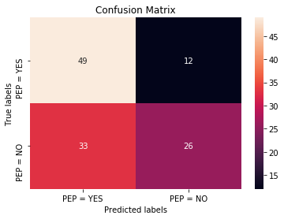

```python
K = 6
knn = neighbors.KNeighborsClassifier(K)
knn.fit(X_train, y_train)
knnpreds_test = knn.predict(X_test)

print(confusion_matrix(y_test, knnpreds_test))
print("\n")
print(classification_report(y_test, knnpreds_test))

# Using HeatMap courtesy of @akilat90 via StackOverflow:
# https://stackoverflow.com/questions/19233771/sklearn-plot-confusion-matrix-with-labels

import seaborn as sns
import matplotlib.pyplot as plt

ax = plt.subplot()
sns.heatmap(confusion_matrix(y_test, knnpreds_test), annot=True, ax = ax);

ax.set_xlabel('Predicted labels');ax.set_ylabel('True labels');
ax.set_title('Confusion Matrix');
ax.xaxis.set_ticklabels(['PEP = YES', 'PEP = NO']); ax.yaxis.set_ticklabels(['PEP = YES', 'PEP = NO']);
```

```python
# Then with weighting

for i in range(1,11):
    K = i
    knn = neighbors.KNeighborsClassifier(K, weights='distance')
    knn.fit(X_train, y_train)
    train_score = knn.score(X_train, y_train)
    test_score = knn.score(X_test, y_test)
    print("K:",K)
    print("Train:",train_score)
    print("Test: ",test_score)
    print("\n")
```

```
K: 1
Train: 1.0
Test:  0.5833333333333334


K: 2
Train: 1.0
Test:  0.5833333333333334


K: 3
Train: 1.0
Test:  0.625


K: 4
Train: 1.0
Test:  0.5916666666666667


K: 5
Train: 1.0
Test:  0.6416666666666667


K: 6
Train: 1.0
Test:  0.625


K: 7
Train: 1.0
Test:  0.6333333333333333


K: 8
Train: 1.0
Test:  0.6166666666666667


K: 9
Train: 1.0
Test:  0.625


K: 10
Train: 1.0
Test:  0.6
```

```
[[43 18]
 [25 34]]
              precision    recall  f1-score   support

          NO       0.63      0.70      0.67        61
         YES       0.65      0.58      0.61        59

    accuracy                           0.64       120
   macro avg       0.64      0.64      0.64       120
weighted avg       0.64      0.64      0.64       120
```

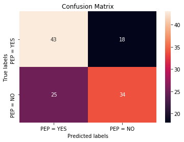

```python
K = 5
knn = neighbors.KNeighborsClassifier(K, weights='distance')
knn.fit(X_train, y_train)
knnpreds_test = knn.predict(X_test)
print(confusion_matrix(y_test, knnpreds_test))
print(classification_report(y_test, knnpreds_test))

# Using HeatMap courtesy of @akilat90 via StackOverflow:
# https://stackoverflow.com/questions/19233771/sklearn-plot-confusion-matrix-with-labels

ax = plt.subplot()
sns.heatmap(confusion_matrix(y_test, knnpreds_test), annot=True, ax = ax);

ax.set_xlabel('Predicted labels');ax.set_ylabel('True labels');
ax.set_title('Confusion Matrix');
ax.xaxis.set_ticklabels(['PEP = YES', 'PEP = NO']); ax.yaxis.set_ticklabels(['PEP = YES', 'PEP = NO']);
```

The accuracies are pretty similar, but the best K I found was for weighted distance with K = 5. I checked K = 1 - 10 for both weighted and unweighted distances. It's important to note that with weighting there was substantial overfitting . All of my K values generated a training accuracy of 1.0 with distance weighting, yet the test results were not much different than those generated without weighting.

Using the non-normalized training and test data, perform classification using scikit-learn's decision tree classifier (using the default parameters).

```python
# First break up training and testing data from non-normalized dataset

SEED = 0

X_train, X_test, y_train, y_test = train_test_split(X_ssf, y, test_size=0.2, random_state=SEED)
X_test.head(10)
```

|  | age | income | children | gender_FEMALE | gender_MALE | region_INNER_CITY | region_RURAL | region_SUBURBAN | region_TOWN | married_NO | married_YES | car_NO | car_YES | savings_acct_NO | savings_acct_YES | current_acct_NO | current_acct_YES | mortgage_NO | mortgage_YES |
| --- | --- | --- | --- | --- | --- | --- | --- | --- | --- | --- | --- | --- | --- | --- | --- | --- | --- | --- | --- |
| 434 | 47 | 23038.2 | 0 | 0 | 1 | 1 | 0 | 0 | 0 | 0 | 1 | 0 | 1 | 0 | 1 | 1 | 0 | 1 | 0 |
| 122 | 36 | 20799.0 | 1 | 1 | 0 | 0 | 0 | 0 | 1 | 0 | 1 | 1 | 0 | 0 | 1 | 1 | 0 | 0 | 1 |
| 224 | 57 | 49874.4 | 3 | 0 | 1 | 0 | 1 | 0 | 0 | 0 | 1 | 1 | 0 | 0 | 1 | 0 | 1 | 1 | 0 |
| 479 | 46 | 43395.5 | 1 | 0 | 1 | 0 | 0 | 0 | 1 | 1 | 0 | 0 | 1 | 0 | 1 | 0 | 1 | 1 | 0 |
| 205 | 18 | 14388.6 | 0 | 0 | 1 | 1 | 0 | 0 | 0 | 1 | 0 | 0 | 1 | 1 | 0 | 0 | 1 | 0 | 1 |
| 569 | 49 | 17944.2 | 1 | 0 | 1 | 1 | 0 | 0 | 0 | 1 | 0 | 0 | 1 | 0 | 1 | 0 | 1 | 0 | 1 |
| 432 | 46 | 16849.3 | 0 | 0 | 1 | 0 | 0 | 0 | 1 | 1 | 0 | 0 | 1 | 0 | 1 | 0 | 1 | 0 | 1 |
| 526 | 32 | 14511.8 | 2 | 0 | 1 | 1 | 0 | 0 | 0 | 1 | 0 | 1 | 0 | 0 | 1 | 1 | 0 | 0 | 1 |
| 439 | 19 | 15417.1 | 1 | 0 | 1 | 1 | 0 | 0 | 0 | 0 | 1 | 0 | 1 | 1 | 0 | 0 | 1 | 1 | 0 |
| 162 | 49 | 20708.5 | 3 | 1 | 0 | 0 | 0 | 0 | 1 | 1 | 0 | 1 | 0 | 1 | 0 | 0 | 1 | 1 | 0 |

```python
treeclf = tree.DecisionTreeClassifier()
treeclf = treeclf.fit(X_train, y_train)
treepreds_test = treeclf.predict(X_test)
```

As above, generate the confusion matrix, classification report, and average accuracy scores the classifier.

```
[[51 10]
 [14 45]]


              precision    recall  f1-score   support

          NO       0.78      0.84      0.81        61
         YES       0.82      0.76      0.79        59

    accuracy                           0.80       120
   macro avg       0.80      0.80      0.80       120
weighted avg       0.80      0.80      0.80       120
```

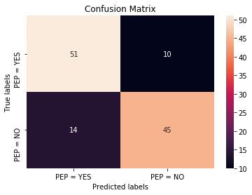

```python
# TESTING

print(confusion_matrix(y_test, treepreds_test))
print("\n")
print(classification_report(y_test, treepreds_test))

# Using HeatMap courtesy of @akilat90 via StackOverflow:
# https://stackoverflow.com/questions/19233771/sklearn-plot-confusion-matrix-with-labels

ax = plt.subplot()
sns.heatmap(confusion_matrix(y_test, treepreds_test), annot=True, ax = ax);

ax.set_xlabel('Predicted labels');ax.set_ylabel('True labels');
ax.set_title('Confusion Matrix');
ax.xaxis.set_ticklabels(['PEP = YES', 'PEP = NO']); ax.yaxis.set_ticklabels(['PEP = YES', 'PEP = NO']);
```

Compare the average accuracy score on the test and the training data sets. What does the comparison tell you in terms of bias-variance trade-off?

```python
print("Train:",treeclf.score(X_train, y_train))
print("Test: ",treeclf.score(X_test, y_test))
```

```
Train: 1.0
Test:  0.8
```

In this instance, it appears that we have a low bias and high variance which has led to overfitting. We would like to increase the bias and decrease the variance so that our model will generalize better on new datapoints.

Create another decision tree model (trained on the non-normalized training data) using "entropy" as the selection criteria, min_samples_split=10, and max_depth=5. For this model generate a visualization of tree and submit it as a separate file (png, jpg, or pdf) or embed it in the Jupyter Notebook.

```python
treeclf = tree.DecisionTreeClassifier(criterion='entropy', min_samples_split=10, max_depth=5)
treeclf = treeclf.fit(X_train, y_train)
```

```python
!pip install graphviz
```

```python
import graphviz
from sklearn.tree import export_graphviz

OUT_PATH = "/Users/claytoncohn/Dropbox/New/DePaul/DSC478/Assignment2/"

export_graphviz(treeclf,out_file=OUT_PATH + 'tree.dot', feature_names=X_train.columns, class_names=y_train.unique(),rounded=True, filled=True)
```

```python
# Will convert to .png to make more readable inline
from graphviz import render
render('dot', 'png', OUT_PATH + 'tree.dot')
```

```
'/Users/claytoncohn/Dropbox/New/DePaul/DSC478/Assignment2/tree.dot.png'
```

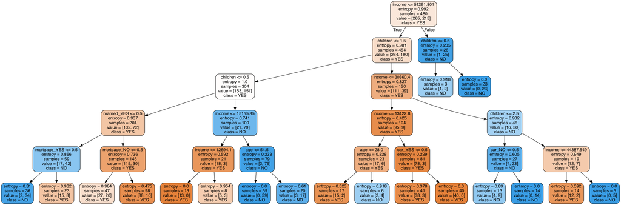

```python
from IPython.display import Image
Image(filename=OUT_PATH + 'tree.dot.png')
```

3. Data Analysis and Predictive Modeling on Census data [Dataset: adult-modified.csv]  
For this problem you will use a simplified version of the Adult Census Data Set. In the subset provided here, some of the attributes have been removed and some preprocessing has been performed.

Your tasks in this problem are the following:

Preprocessing and data analysis:

```python
DATA_PATH = "/Users/claytoncohn/Dropbox/New/DePaul/DSC478/data/"

X = pd.read_csv(DATA_PATH + "adult-modified.csv")
X.head(10)
```

|  | age | workclass | education | marital-status | race | sex | hours-per-week | income |
| --- | --- | --- | --- | --- | --- | --- | --- | --- |
| 0 | 39 | Public | 13 | Single | White | Male | 40 | <=50K |
| 1 | 50 | Self-emp | 13 | Married | White | Male | 13 | <=50K |
| 2 | 38 | Private | 9 | Single | White | Male | 40 | <=50K |
| 3 | 53 | Private | 7 | Married | Black | Male | 40 | <=50K |
| 4 | 28 | Private | 13 | Married | Black | Female | 40 | <=50K |
| 5 | 37 | Private | 14 | Married | White | Female | 40 | <=50K |
| 6 | 49 | Private | 5 | Married | Black | Female | 16 | <=50K |
| 7 | 52 | Self-emp | 9 | Married | White | Male | 45 | >50K |
| 8 | 31 | Private | 14 | Single | White | Female | 50 | >50K |
| 9 | 42 | Private | 13 | Married | White | Male | 40 | >50K |

Examine the data for missing values. In case of categorical attributes, remove instances with missing values. In the case of numeric attributes, impute and fill-in the missing values using the attribute mean.

```python
# First replace ? chars with NaN values
X.age = X.age.replace({'?': np.nan})

# Convert column to float
X.age = X.age.astype(np.float64)

# Get mean of column
age_mean = float(X.age.mean())

# Replace NaN with mean
X.age.fillna(age_mean, inplace=True)

X.head(30)
```

|  | age | workclass | education | marital-status | race | sex | hours-per-week | income |
| --- | --- | --- | --- | --- | --- | --- | --- | --- |
| 0 | 39.000000 | Public | 13 | Single | White | Male | 40 | <=50K |
| 1 | 50.000000 | Self-emp | 13 | Married | White | Male | 13 | <=50K |
| 2 | 38.000000 | Private | 9 | Single | White | Male | 40 | <=50K |
| 3 | 53.000000 | Private | 7 | Married | Black | Male | 40 | <=50K |
| 4 | 28.000000 | Private | 13 | Married | Black | Female | 40 | <=50K |
| 5 | 37.000000 | Private | 14 | Married | White | Female | 40 | <=50K |
| 6 | 49.000000 | Private | 5 | Married | Black | Female | 16 | <=50K |
| 7 | 52.000000 | Self-emp | 9 | Married | White | Male | 45 | >50K |
| 8 | 31.000000 | Private | 14 | Single | White | Female | 50 | >50K |
| 9 | 42.000000 | Private | 13 | Married | White | Male | 40 | >50K |
| 10 | 37.000000 | Private | 10 | Married | Black | Male | 80 | >50K |
| 11 | 30.000000 | Public | 13 | Married | Asian | Male | 40 | >50K |
| 12 | 23.000000 | Private | 13 | Single | White | Female | 30 | <=50K |
| 13 | 32.000000 | Private | 12 | Single | Black | Male | 50 | <=50K |
| 14 | 40.000000 | Private | 11 | Married | Asian | Male | 40 | >50K |
| 15 | 34.000000 | Private | 4 | Married | Amer-Indian | Male | 45 | <=50K |
| 16 | 25.000000 | Self-emp | 9 | Single | White | Male | 35 | <=50K |
| 17 | 32.000000 | Private | 9 | Single | White | Male | 40 | <=50K |
| 18 | 38.000000 | Private | 7 | Married | White | Male | 50 | <=50K |
| 19 | 38.449806 | Self-emp | 14 | Single | White | Female | 45 | >50K |
| 20 | 40.000000 | Private | 16 | Married | White | Male | 60 | >50K |
| 21 | 54.000000 | Private | 9 | Single | Black | Female | 20 | <=50K |
| 22 | 35.000000 | Public | 5 | Married | Black | Male | 40 | <=50K |
| 23 | 43.000000 | Private | 7 | Married | White | Male | 40 | <=50K |
| 24 | 59.000000 | Private | 9 | Single | White | Female | 40 | <=50K |
| 25 | 56.000000 | Public | 13 | Married | White | Male | 40 | >50K |
| 26 | 19.000000 | Private | 9 | Single | White | Male | 40 | <=50K |
| 27 | 38.449806 | ? | 10 | Married | Asian | Male | 60 | >50K |
| 28 | 39.000000 | Private | 9 | Single | White | Male | 80 | <=50K |
| 29 | 49.000000 | Private | 9 | Married | White | Male | 40 | <=50K |

```python
# Drop rows with categorical unknowns
X_processed = X[X['workclass'] != '?']
X_processed.head(30)
```

|  | age | workclass | education | marital-status | race | sex | hours-per-week | income |
| --- | --- | --- | --- | --- | --- | --- | --- | --- |
| 0 | 39.000000 | Public | 13 | Single | White | Male | 40 | <=50K |
| 1 | 50.000000 | Self-emp | 13 | Married | White | Male | 13 | <=50K |
| 2 | 38.000000 | Private | 9 | Single | White | Male | 40 | <=50K |
| 3 | 53.000000 | Private | 7 | Married | Black | Male | 40 | <=50K |
| 4 | 28.000000 | Private | 13 | Married | Black | Female | 40 | <=50K |
| 5 | 37.000000 | Private | 14 | Married | White | Female | 40 | <=50K |
| 6 | 49.000000 | Private | 5 | Married | Black | Female | 16 | <=50K |
| 7 | 52.000000 | Self-emp | 9 | Married | White | Male | 45 | >50K |
| 8 | 31.000000 | Private | 14 | Single | White | Female | 50 | >50K |
| 9 | 42.000000 | Private | 13 | Married | White | Male | 40 | >50K |
| 10 | 37.000000 | Private | 10 | Married | Black | Male | 80 | >50K |
| 11 | 30.000000 | Public | 13 | Married | Asian | Male | 40 | >50K |
| 12 | 23.000000 | Private | 13 | Single | White | Female | 30 | <=50K |
| 13 | 32.000000 | Private | 12 | Single | Black | Male | 50 | <=50K |
| 14 | 40.000000 | Private | 11 | Married | Asian | Male | 40 | >50K |
| 15 | 34.000000 | Private | 4 | Married | Amer-Indian | Male | 45 | <=50K |
| 16 | 25.000000 | Self-emp | 9 | Single | White | Male | 35 | <=50K |
| 17 | 32.000000 | Private | 9 | Single | White | Male | 40 | <=50K |
| 18 | 38.000000 | Private | 7 | Married | White | Male | 50 | <=50K |
| 19 | 38.449806 | Self-emp | 14 | Single | White | Female | 45 | >50K |
| 20 | 40.000000 | Private | 16 | Married | White | Male | 60 | >50K |
| 21 | 54.000000 | Private | 9 | Single | Black | Female | 20 | <=50K |
| 22 | 35.000000 | Public | 5 | Married | Black | Male | 40 | <=50K |
| 23 | 43.000000 | Private | 7 | Married | White | Male | 40 | <=50K |
| 24 | 59.000000 | Private | 9 | Single | White | Female | 40 | <=50K |
| 25 | 56.000000 | Public | 13 | Married | White | Male | 40 | >50K |
| 26 | 19.000000 | Private | 9 | Single | White | Male | 40 | <=50K |
| 28 | 39.000000 | Private | 9 | Single | White | Male | 80 | <=50K |
| 29 | 49.000000 | Private | 9 | Married | White | Male | 40 | <=50K |
| 30 | 23.000000 | Public | 12 | Single | White | Male | 52 | <=50K |

Examine the characteristics of the attributes, including **summary statistics** for the attributes, **histograms** illustrating the distribtions of numeric attributes, and **bar graphs** showing value counts for categorical attributes.

```python
X_processed.describe(include="all")
```

|  | age | workclass | education | marital-status | race | sex | hours-per-week | income |
| --- | --- | --- | --- | --- | --- | --- | --- | --- |
| count | 9412.000000 | 9412 | 9412.000000 | 9412 | 9412 | 9412 | 9412.000000 | 9412 |
| unique | NaN | 3 | NaN | 2 | 5 | 2 | NaN | 2 |
| top | NaN | Private | NaN | Married | White | Male | NaN | <=50K |
| freq | NaN | 6947 | NaN | 4737 | 8062 | 6383 | NaN | 7093 |
| mean | 38.366342 | NaN | 10.125266 | NaN | NaN | NaN | 41.080217 | NaN |
| std | 12.962039 | NaN | 2.542118 | NaN | NaN | NaN | 11.884590 | NaN |
| min | 17.000000 | NaN | 1.000000 | NaN | NaN | NaN | 1.000000 | NaN |
| 25% | 28.000000 | NaN | 9.000000 | NaN | NaN | NaN | 40.000000 | NaN |
| 50% | 37.000000 | NaN | 10.000000 | NaN | NaN | NaN | 40.000000 | NaN |
| 75% | 47.000000 | NaN | 13.000000 | NaN | NaN | NaN | 45.000000 | NaN |
| max | 90.000000 | NaN | 16.000000 | NaN | NaN | NaN | 99.000000 | NaN |

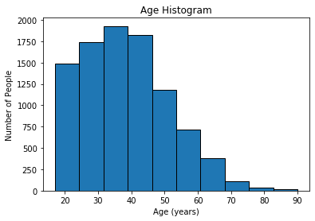

```python
age = X_processed.age
ax = age.plot(kind="hist", bins=10, ec='black',title="Age Histogram")
ax.set_xlabel("Age (years)")
ax.set_ylabel("Number of People")
```

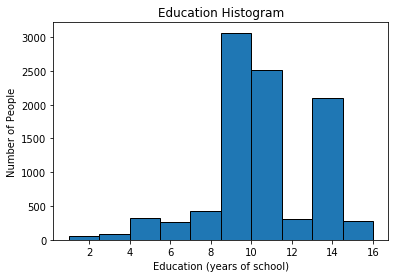

```python
education = X_processed.education
ax1 = education.plot(kind="hist", bins=10, ec='black',title="Education Histogram")
ax1.set_xlabel("Education (years of school)")
ax1.set_ylabel("Number of People")
```

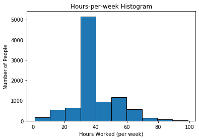

```python
hpw = X_processed["hours-per-week"]
ax2 = hpw.plot(kind="hist", bins=10, ec='black',title="Hours-per-week Histogram")
ax2.set_xlabel("Hours Worked (per week)")
ax2.set_ylabel("Number of People")
```

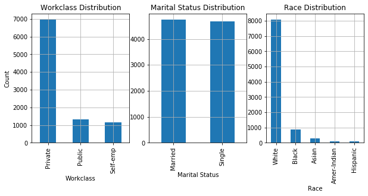

```python
# categorical attributes - workclass
workclass = X_processed["workclass"].value_counts()
fig = plt.figure(figsize=(10,4))
ax3 = fig.add_subplot(131)
ax3.set_xlabel('Workclass')
ax3.set_ylabel('Count')
ax3.set_title("Workclass Distribution")
workclass.plot(kind='bar', grid = True)

# categorical attributes - marital status
ms = X_processed["marital-status"].value_counts()
ax3 = fig.add_subplot(132)
ax3.set_xlabel('Marital Status')
ax3.set_title("Marital Status Distribution")
ms.plot(kind='bar', grid = True)

# categorical attributes - race
race = X_processed["race"].value_counts()
ax3 = fig.add_subplot(133)
ax3.set_xlabel('Race')
ax3.set_title("Race Distribution")
race.plot(kind='bar', grid = True)
```

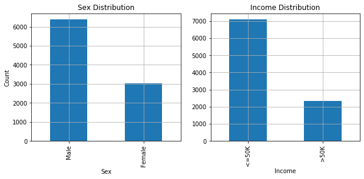

```python
# categorical attributes - sex
sex = X_processed["sex"].value_counts()
fig = plt.figure(figsize=(10,4))
ax4 = fig.add_subplot(121)
ax4.set_xlabel('Sex')
ax4.set_ylabel('Count')
ax4.set_title("Sex Distribution")
sex.plot(kind='bar', grid = True)

# categorical attributes - marital status
income = X_processed["income"].value_counts()
ax4 = fig.add_subplot(122)
ax4.set_xlabel('Income')
ax4.set_title("Income Distribution")
income.plot(kind='bar', grid = True)
```

Perform the following cross-tabulations (including generating bar charts):  
education+race,  
work-class+income,  
work-class+race,  
and race+income.

```
race       Amer-Indian  Asian  Black  Hispanic  White
education
1                    0      0      1         0     11
2                    0      1      4         3     38
3                    0      4      5         1     71
4                    5      5     14         6    150
5                    0      3     19         2    118
6                    8      3     30         4    223
7                    4      6     49         4    261
8                    0      2     17         3     78
9                   35     67    350        23   2590
10                  26     64    206        11   1818
11                   5     10     33         4    337
12                   4      5     33         3    259
13                   5     75    102         8   1387
14                   0     27     20         1    467
15                   0     11      5         2    153
16                   0      8      4         0    101
```

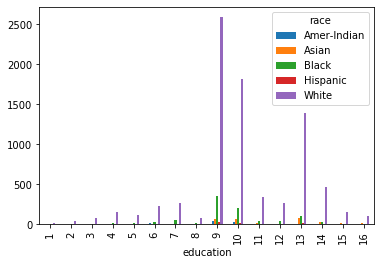

```python
# education + race
ed_race = pd.crosstab(X_processed["education"], X_processed["race"])
print(ed_race)
plt.show(ed_race.plot(kind="bar"))
```

```
income     <=50K  >50K
workclass
Private     5443  1504
Public       925   392
Self-emp     725   423
```

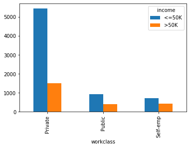

```python
# work-class + income
wc_income = pd.crosstab(X_processed["workclass"], X_processed["income"])
print(wc_income)
plt.show(wc_income.plot(kind="bar"))
```

```
race       Amer-Indian  Asian  Black  Hispanic  White
workclass
Private             65    204    664        64   5950
Public              20     48    192         5   1052
Self-emp             7     39     36         6   1060
```

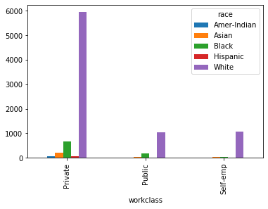

```python
# work-class + race
wc_race = pd.crosstab(X_processed["workclass"], X_processed["race"])
print(wc_race)
plt.show(wc_race.plot(kind="bar"))
```

```
race    Amer-Indian  Asian  Black  Hispanic  White
income
<=50K            83    224    773        69   5944
>50K              9     67    119         6   2118
```

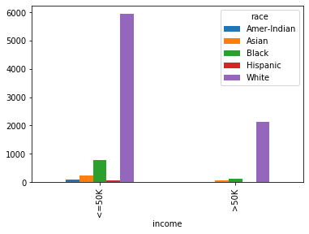

```python
# income + race
income_race = pd.crosstab(X_processed["income"], X_processed["race"])
print(income_race)
plt.show(income_race.plot(kind="bar"))
```

In the latter case (race+income) also create a table or chart showing percentages of each race category that fall in the low-income group. Discuss your observations from this analysis.

```python
# high income
high_income = X_processed[X_processed['income'] == '>50K']
high_income['race'].value_counts(normalize=True) * 100
```

```
White          91.332471
Black           5.131522
Asian           2.889176
Amer-Indian     0.388098
Hispanic        0.258732
Name: race, dtype: float64
```

```python
# low income
low_income = X_processed[X_processed['income'] == '<=50K']
low_income['race'].value_counts(normalize=True) * 100
```

```
White          83.800930
Black          10.898069
Asian           3.158043
Amer-Indian     1.170168
Hispanic        0.972790
Name: race, dtype: float64
```

```python
# overall income
X_processed['race'].value_counts(normalize=True) * 100
```

```
White          85.656609
Black           9.477263
Asian           3.091798
Amer-Indian     0.977476
Hispanic        0.796855
Name: race, dtype: float64
```

The vast majority (~86%) of participants identified as White, but there was an uptick across the board in non-whites categorized in low income, and a downtick across the board in non-whites categorized in high income. This suggests that in this particular dataset White-identifying individuals tended to have higher incomes.

Compare and contrast the characteristics of the low-income and high-income categories across the different attributes.

```python
# Sex and income

# high income
print("High income sex:\n{0}\n\n".format(high_income['sex'].value_counts(normalize=True) * 100))

# low income
print("Low income sex:\n{0}\n\n".format(low_income['sex'].value_counts(normalize=True) * 100))

# overall income
print("Overall income sex:\n{0}".format(X_processed['sex'].value_counts(normalize=True) * 100))
```

```
High income sex:
Male      84.476067
Female    15.523933
Name: sex, dtype: float64


Low income sex:
Male      62.371352
Female    37.628648
Name: sex, dtype: float64


Overall income sex:
Male      67.81768
Female    32.18232
Name: sex, dtype: float64
```

Comparing sex and income, roughly 2/3 of all participants were male, but only 15% of the high income category was composed of females. Similarly, females made up a higher percentage of the low income category than they did overall.

```python
# Workclass and income

# high income
print("High income workclass:\n{0}\n\n".format(high_income['workclass'].value_counts(normalize=True) * 100))

# low income
print("Low income workclass:\n{0}\n\n".format(low_income['workclass'].value_counts(normalize=True) * 100))

# overall income
print("Overall income workclass:\n{0}".format(X_processed['workclass'].value_counts(normalize=True) * 100))
```

```
High income workclass:
Private     64.855541
Self-emp    18.240621
Public      16.903838
Name: workclass, dtype: float64


Low income workclass:
Private     76.737629
Public      13.041026
Self-emp    10.221345
Name: workclass, dtype: float64


Overall income workclass:
Private     73.810030
Public      13.992775
Self-emp    12.197195
Name: workclass, dtype: float64
```

Comparing workclass and income, roughly 74% of all participants were employed in the private sector, but only 65% of the high income category was composed of private sector employees. Similarly, private sector employees made up a higher percentage of the low income category than they did overall.

```python
# Marital status and income

# high income
print("High income marital status:\n{0}\n\n".format(high_income['marital-status'].value_counts(normalize=True) * 100))

# low income
print("Low income marital status:\n{0}\n\n".format(low_income['marital-status'].value_counts(normalize=True) * 100))

# overall income
print("Overall income marital status:\n{0}".format(X_processed['marital-status'].value_counts(normalize=True) * 100))
```

```
High income marital status:
Married    86.545925
Single     13.454075
Name: marital-status, dtype: float64


Low income marital status:
Single     61.511349
Married    38.488651
Name: marital-status, dtype: float64


Overall income marital status:
Married    50.329367
Single     49.670633
Name: marital-status, dtype: float64
```

This is the most significant split yet. Overall, the dataset is split almost evenly between those who are married and those who aren't, yet married individuals make up a whopping 87% of the high income cases, and single individuals make up 62% of the low income cases.

Predictive Modeling and Model Evaluation:

Using either Pandas or Scikit-learn, create dummy variables for the categorical attributes.

```python
# Replace categorical variables with dummies
X_ssf = pd.get_dummies(X_processed,columns=['workclass','marital-status','race','sex','income'])
X_ssf.head(10)
```

|  | age | education | hours-per-week | workclass_Private | workclass_Public | workclass_Self-emp | marital-status_Married | marital-status_Single | race_Amer-Indian | race_Asian | race_Black | race_Hispanic | race_White | sex_Female | sex_Male | income_<=50K | income_>50K |
| --- | --- | --- | --- | --- | --- | --- | --- | --- | --- | --- | --- | --- | --- | --- | --- | --- | --- |
| 0 | 39.0 | 13 | 40 | 0 | 1 | 0 | 0 | 1 | 0 | 0 | 0 | 0 | 1 | 0 | 1 | 1 | 0 |
| 1 | 50.0 | 13 | 13 | 0 | 0 | 1 | 1 | 0 | 0 | 0 | 0 | 0 | 1 | 0 | 1 | 1 | 0 |
| 2 | 38.0 | 9 | 40 | 1 | 0 | 0 | 0 | 1 | 0 | 0 | 0 | 0 | 1 | 0 | 1 | 1 | 0 |
| 3 | 53.0 | 7 | 40 | 1 | 0 | 0 | 1 | 0 | 0 | 0 | 1 | 0 | 0 | 0 | 1 | 1 | 0 |
| 4 | 28.0 | 13 | 40 | 1 | 0 | 0 | 1 | 0 | 0 | 0 | 1 | 0 | 0 | 1 | 0 | 1 | 0 |
| 5 | 37.0 | 14 | 40 | 1 | 0 | 0 | 1 | 0 | 0 | 0 | 0 | 0 | 1 | 1 | 0 | 1 | 0 |
| 6 | 49.0 | 5 | 16 | 1 | 0 | 0 | 1 | 0 | 0 | 0 | 1 | 0 | 0 | 1 | 0 | 1 | 0 |
| 7 | 52.0 | 9 | 45 | 0 | 0 | 1 | 1 | 0 | 0 | 0 | 0 | 0 | 1 | 0 | 1 | 0 | 1 |
| 8 | 31.0 | 14 | 50 | 1 | 0 | 0 | 0 | 1 | 0 | 0 | 0 | 0 | 1 | 1 | 0 | 0 | 1 |
| 9 | 42.0 | 13 | 40 | 1 | 0 | 0 | 1 | 0 | 0 | 0 | 0 | 0 | 1 | 0 | 1 | 0 | 1 |

```python
# Set target variable
y = X_ssf['income_>50K']
y.head(10)
```

```
0    0
1    0
2    0
3    0
4    0
5    0
6    0
7    1
8    1
9    1
Name: income_>50K, dtype: uint8
```

Then separate the target attribute ("income*>50K") from the attributes used for training. [Note: you need to drop "income*<=50K" which is also created as a dummy variable in earlier steps).

```python
X_ssf = X_ssf.drop(['income_<=50K','income_>50K'],axis=1)
X_ssf.head(10)
```

|  | age | education | hours-per-week | workclass_Private | workclass_Public | workclass_Self-emp | marital-status_Married | marital-status_Single | race_Amer-Indian | race_Asian | race_Black | race_Hispanic | race_White | sex_Female | sex_Male |
| --- | --- | --- | --- | --- | --- | --- | --- | --- | --- | --- | --- | --- | --- | --- | --- |
| 0 | 39.0 | 13 | 40 | 0 | 1 | 0 | 0 | 1 | 0 | 0 | 0 | 0 | 1 | 0 | 1 |
| 1 | 50.0 | 13 | 13 | 0 | 0 | 1 | 1 | 0 | 0 | 0 | 0 | 0 | 1 | 0 | 1 |
| 2 | 38.0 | 9 | 40 | 1 | 0 | 0 | 0 | 1 | 0 | 0 | 0 | 0 | 1 | 0 | 1 |
| 3 | 53.0 | 7 | 40 | 1 | 0 | 0 | 1 | 0 | 0 | 0 | 1 | 0 | 0 | 0 | 1 |
| 4 | 28.0 | 13 | 40 | 1 | 0 | 0 | 1 | 0 | 0 | 0 | 1 | 0 | 0 | 1 | 0 |
| 5 | 37.0 | 14 | 40 | 1 | 0 | 0 | 1 | 0 | 0 | 0 | 0 | 0 | 1 | 1 | 0 |
| 6 | 49.0 | 5 | 16 | 1 | 0 | 0 | 1 | 0 | 0 | 0 | 1 | 0 | 0 | 1 | 0 |
| 7 | 52.0 | 9 | 45 | 0 | 0 | 1 | 1 | 0 | 0 | 0 | 0 | 0 | 1 | 0 | 1 |
| 8 | 31.0 | 14 | 50 | 1 | 0 | 0 | 0 | 1 | 0 | 0 | 0 | 0 | 1 | 1 | 0 |
| 9 | 42.0 | 13 | 40 | 1 | 0 | 0 | 1 | 0 | 0 | 0 | 0 | 0 | 1 | 0 | 1 |

Split the data into training and test sets (80%-20% split).

```python
SEED = 0

X_train, X_test, y_train, y_test = train_test_split(X_ssf, y, test_size=0.2, random_state=SEED)
X_test.head(10)
```

|  | age | education | hours-per-week | workclass_Private | workclass_Public | workclass_Self-emp | marital-status_Married | marital-status_Single | race_Amer-Indian | race_Asian | race_Black | race_Hispanic | race_White | sex_Female | sex_Male |
| --- | --- | --- | --- | --- | --- | --- | --- | --- | --- | --- | --- | --- | --- | --- | --- |
| 6874 | 17.0 | 6 | 10 | 1 | 0 | 0 | 0 | 1 | 0 | 0 | 0 | 0 | 1 | 0 | 1 |
| 9984 | 28.0 | 6 | 48 | 1 | 0 | 0 | 1 | 0 | 0 | 0 | 0 | 1 | 0 | 1 | 0 |
| 4093 | 31.0 | 14 | 40 | 0 | 1 | 0 | 1 | 0 | 0 | 0 | 0 | 0 | 1 | 0 | 1 |
| 3658 | 21.0 | 10 | 30 | 1 | 0 | 0 | 0 | 1 | 0 | 0 | 1 | 0 | 0 | 1 | 0 |
| 4281 | 64.0 | 4 | 30 | 0 | 1 | 0 | 1 | 0 | 0 | 0 | 0 | 0 | 1 | 1 | 0 |
| 3864 | 50.0 | 9 | 40 | 0 | 1 | 0 | 1 | 0 | 0 | 0 | 1 | 0 | 0 | 0 | 1 |
| 8744 | 22.0 | 9 | 50 | 0 | 1 | 0 | 0 | 1 | 0 | 0 | 0 | 0 | 1 | 0 | 1 |
| 2563 | 54.0 | 9 | 20 | 0 | 1 | 0 | 0 | 1 | 0 | 0 | 0 | 0 | 1 | 1 | 0 |
| 5237 | 21.0 | 10 | 20 | 1 | 0 | 0 | 0 | 1 | 0 | 0 | 0 | 0 | 1 | 1 | 0 |
| 9980 | 29.0 | 13 | 40 | 1 | 0 | 0 | 0 | 1 | 0 | 0 | 0 | 0 | 1 | 0 | 1 |

Use scikit-learn to build classifiers using  
Naive Bayes (Gaussian),  
decision tree (using "gini" as selection criteria),  
and linear discriminant analysis (LDA).

For each of these perform 10-fold cross-validation on the training data (using cross-validation module in scikit-learn) and report the overall average accuracy.

Compare this to the model accuracy on the training data. Finally, run your model on the set-aside test data.

```python
from sklearn.model_selection import cross_val_score

# Naive Bayes (Gaussian) (cross-validation)
nbclf = naive_bayes.GaussianNB()
cv_scores = cross_val_score(nbclf, X_train, y_train, cv=5)
print("Overall Accuracy (cross-validation): %0.2f (+/- %0.2f)" % (cv_scores.mean(), cv_scores.std() * 2))
```

```
Overall Accuracy (cross-validation): 0.72 (+/- 0.02)
```

```python
# Naive Bayes training accuracy
nbclf = nbclf.fit(X_train, y_train)
print("Accuracy on Training: ", nbclf.score(X_train, y_train))
```

```
Accuracy on Training:  0.7209456767166954
```

```python
# Naive Bayes testing accuracy
print("Accuracy on Testing: ", nbclf.score(X_test, y_test))
```

```
Accuracy on Testing:  0.7217206585236325
```

```python
# Naive Bayes stats
nbclfpreds_test = nbclf.predict(X_test)

print(confusion_matrix(y_test, nbclfpreds_test))
print("\n")
print(classification_report(y_test, nbclfpreds_test))
```

```
[[1002  412]
 [ 112  357]]


              precision    recall  f1-score   support

           0       0.90      0.71      0.79      1414
           1       0.46      0.76      0.58       469

    accuracy                           0.72      1883
   macro avg       0.68      0.73      0.68      1883
weighted avg       0.79      0.72      0.74      1883
```

```python
# Decision Tree (Gini) (cross-validation)
treeclf = tree.DecisionTreeClassifier(criterion='gini')
cv_scores = cross_val_score(treeclf, X_train, y_train, cv=5)
print("Overall Accuracy (cross-validation): %0.2f (+/- %0.2f)" % (cv_scores.mean(), cv_scores.std() * 2))
```

```
Overall Accuracy (cross-validation): 0.77 (+/- 0.02)
```

```python
# Decision Tree training accuracy
treeclf = treeclf.fit(X_train, y_train)
print("Accuracy on Training: ", treeclf.score(X_train, y_train))
```

```
Accuracy on Training:  0.9419577633151813
```

```python
# Decision Tree testing accuracy
print("Accuracy on Testing: ", treeclf.score(X_test, y_test))
```

```
Accuracy on Testing:  0.7679235262878386
```

```python
# Decision Tree stats
treepreds_test = treeclf.predict(X_test)

print(confusion_matrix(y_test, treepreds_test))
print("\n")
print(classification_report(y_test, treepreds_test))
```

```
[[1219  195]
 [ 242  227]]


              precision    recall  f1-score   support

           0       0.83      0.86      0.85      1414
           1       0.54      0.48      0.51       469

    accuracy                           0.77      1883
   macro avg       0.69      0.67      0.68      1883
weighted avg       0.76      0.77      0.76      1883
```

```python
from sklearn.discriminant_analysis import LinearDiscriminantAnalysis

# Linear Discriminant Analysis (LDA) (cross-validation)
ldclf = LinearDiscriminantAnalysis()
cv_scores = cross_val_score(ldclf, X_train, y_train, cv=5)
print("Overall Accuracy (cross-validation): %0.2f (+/- %0.2f)" % (cv_scores.mean(), cv_scores.std() * 2))
```

```
Overall Accuracy (cross-validation): 0.81 (+/- 0.02)
```

```python
# LDA training accuracy
ldclf = ldclf.fit(X_train, y_train)
print("Accuracy on Training: ", ldclf.score(X_train, y_train))
```

```
Accuracy on Training:  0.8083410811528755
```

```python
# LDA testing accuracy
print("Accuracy on Testing: ", ldclf.score(X_test, y_test))
```

```
Accuracy on Testing:  0.8066914498141264
```

```python
# LDA stats
ldclf_test = ldclf.predict(X_test)

print(confusion_matrix(y_test, treepreds_test))
print("\n")
print(classification_report(y_test, ldclf_test))
```

```
[[1219  195]
 [ 242  227]]


              precision    recall  f1-score   support

           0       0.84      0.92      0.88      1414
           1       0.66      0.47      0.55       469

    accuracy                           0.81      1883
   macro avg       0.75      0.69      0.71      1883
weighted avg       0.79      0.81      0.80      1883
```